# Statistics for Decision Making

### HeroVired CPDA Graded Assignment

**Dataset:** property.csv — Australian Real Estate Prices  
**Author:** Biplab Mitra | **Batch:** CPDA

## Setup & Data Loading

```python
import pandas as pd
import numpy as np
from scipy.stats import ttest_1samp, ttest_ind, binom
from statsmodels.formula.api import ols
from statsmodels.stats.anova import anova_lm
%matplotlib inline
import matplotlib.pyplot as plt
import matplotlib.patches as mpatches
from matplotlib.patches import Patch
import seaborn as sns
sns.set_theme(style="whitegrid")
import warnings
warnings.filterwarnings('ignore')

df = pd.read_csv('../data/raw/property.csv')
df['Date'] = pd.to_datetime(df['Date'], dayfirst=True)
df['Month'] = df['Date'].dt.month
df['Year']  = df['Date'].dt.year

print("Shape:", df.shape)
df.head(3)
```

[output not shown]

## Question 1: One-Sample T-Test — Altona Property Price

**Hypothesis:** Is the typical property price in Altona $800,000, or has it increased? **Significance level:** α = 0.05 **Test:** One-sample t-test (one-tailed, right) — testing whether the population mean has risen above $800,000.

```python
# ── Filter Altona ──────────────────────────────────────────────────────
altona = df[df['Suburb'] == 'Altona']['Price'].dropna()

print("=== Descriptive Statistics — Altona ===")
print(f"  n       : {len(altona)}")
print(f"  Mean    : ${altona.mean():,.2f}")
print(f"  Median  : ${altona.median():,.2f}")
print(f"  Std Dev : ${altona.std():,.2f}")

# ── Hypotheses ─────────────────────────────────────────────────────────
mu_0 = 800_000
print("\n=== Hypotheses ===")
print("  H0 (Null)       : mu = $800,000  (price has NOT changed)")
print("  H1 (Alternative): mu > $800,000  (price has INCREASED)")
print("  Test type       : One-tailed (right tail), alpha = 0.05")

# ── Test ───────────────────────────────────────────────────────────────
t_stat, p_two = ttest_1samp(altona, popmean=mu_0)
p_one = p_two / 2   # divide by 2 for one-tailed right

print("\n=== Test Results ===")
print(f"  T-statistic        : {t_stat:.4f}")
print(f"  Two-tailed p-value : {p_two:.4f}")
print(f"  One-tailed p-value : {p_one:.4f}")

# ── Decision ───────────────────────────────────────────────────────────
print("\n=== Decision (alpha = 0.05) ===")
if p_one < 0.05 and t_stat > 0:
    print("  REJECT H0")
    print("  Conclusion: There is statistically significant evidence that")
    print("  the typical Altona property price has INCREASED above $800,000.")
else:
    print("  FAIL TO REJECT H0")
    print(f"  p-value ({p_one:.4f}) > 0.05 — insufficient evidence to conclude")
    print("  the price has increased. The $800,000 benchmark remains plausible.")
```

```
=== Descriptive Statistics — Altona ===
  n       : 74
  Mean    : $834,830.41
  Median  : $773,500.00
  Std Dev : $291,546.05

=== Hypotheses ===
  H0 (Null)       : mu = $800,000  (price has NOT changed)
  H1 (Alternative): mu > $800,000  (price has INCREASED)
  Test type       : One-tailed (right tail), alpha = 0.05

=== Test Results ===
  T-statistic        : 1.0277
  Two-tailed p-value : 0.3075
  One-tailed p-value : 0.1537

=== Decision (alpha = 0.05) ===
  FAIL TO REJECT H0
  p-value (0.1537) > 0.05 — insufficient evidence to conclude
  the price has increased. The $800,000 benchmark remains plausible.
```

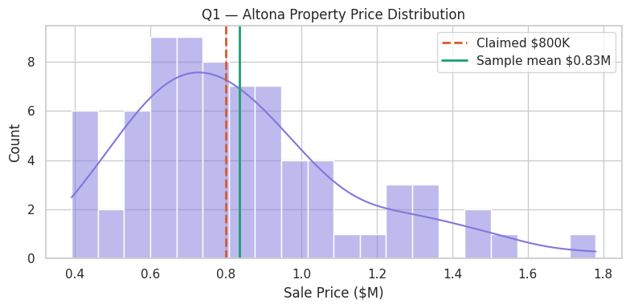

```python
fig, ax = plt.subplots(figsize=(8, 4))
data = altona / 1e6
sns.histplot(data, bins=20, kde=True, ax=ax, color="#7F77DD")
ax.axvline(0.8, color="#D85A30", linewidth=2, linestyle="--", label="Claimed $800K")
ax.axvline(data.mean(), color="#1D9E75", linewidth=2, linestyle="-",
           label=f"Sample mean ${data.mean():.2f}M")
ax.set_xlabel("Sale Price ($M)")
ax.set_ylabel("Count")
ax.set_title("Q1 — Altona Property Price Distribution")
ax.legend()
plt.tight_layout()
plt.show()
```

```python
print("┌─ Q1 — Histogram with KDE")
print("│  Distribution of Altona sale prices. Red dashed = claimed $800K; green = actual sample mean.")
print("└─────────────────────────────────────────────────────────────────────")
```

```
┌─ Q1 — Histogram with KDE
│  Distribution of Altona sale prices. Red dashed = claimed $800K; green = actual sample mean.
└─────────────────────────────────────────────────────────────────────
```

## Question 2: Two-Sample T-Test — Summer vs Winter Prices (2016)

**Hypothesis:** Is there any difference in property prices between summer and winter months in 2016?

- **Winter months:** October–March (10, 11, 12, 1, 2, 3)
- **Summer months:** April–September (4, 5, 6, 7, 8, 9)  
  **Significance level:** α = 0.05  
  **Test:** Welch's independent two-sample t-test (two-tailed — any difference)

```python
# ── Filter 2016 & split by season ─────────────────────────────────────
df_2016 = df[df['Year'] == 2016].copy()

winter_months = [10, 11, 12, 1, 2, 3]
summer_months = [4, 5, 6, 7, 8, 9]

winter = df_2016[df_2016['Month'].isin(winter_months)]['Price'].dropna()
summer = df_2016[df_2016['Month'].isin(summer_months)]['Price'].dropna()

print("=== Descriptive Statistics — 2016 ===")
print(f"  Winter months (Oct-Mar): n={len(winter):,},  Mean=${winter.mean():,.2f},  Std=${winter.std():,.2f}")
print(f"  Summer months (Apr-Sep): n={len(summer):,},  Mean=${summer.mean():,.2f},  Std=${summer.std():,.2f}")

# ── Hypotheses ─────────────────────────────────────────────────────────
print("\n=== Hypotheses ===")
print("  H0 (Null)       : mu_winter = mu_summer  (no price difference between seasons)")
print("  H1 (Alternative): mu_winter != mu_summer (significant difference exists)")
print("  Test type       : Two-tailed, alpha = 0.05")
print("  Test chosen     : Welch's t-test (independent samples, variances not assumed equal)")

# ── Test ───────────────────────────────────────────────────────────────
t_stat, p_val = ttest_ind(winter, summer, equal_var=False)

print("\n=== Test Results ===")
print(f"  T-statistic : {t_stat:.4f}")
print(f"  P-value     : {p_val:.4f}")

# ── Decision ───────────────────────────────────────────────────────────
print("\n=== Decision (alpha = 0.05) ===")
if p_val < 0.05:
    print("  REJECT H0")
    print(f"  p-value ({p_val:.4f}) < 0.05 — statistically significant difference found.")
    print(f"  Winter mean (${winter.mean():,.0f}) > Summer mean (${summer.mean():,.0f}).")
    print("  Conclusion: Property prices in winter months are significantly higher")
    print("  than in summer months for 2016.")
else:
    print("  FAIL TO REJECT H0")
    print("  No statistically significant seasonal price difference in 2016.")
```

```
=== Descriptive Statistics — 2016 ===
  Winter months (Oct-Mar): n=2,300,  Mean=$1,116,647.59,  Std=$695,498.28
  Summer months (Apr-Sep): n=4,036,  Mean=$1,048,054.73,  Std=$621,493.44

=== Hypotheses ===
  H0 (Null)       : mu_winter = mu_summer  (no price difference between seasons)
  H1 (Alternative): mu_winter != mu_summer (significant difference exists)
  Test type       : Two-tailed, alpha = 0.05
  Test chosen     : Welch's t-test (independent samples, variances not assumed equal)

=== Test Results ===
  T-statistic : 3.9211
  P-value     : 0.0001

=== Decision (alpha = 0.05) ===
  REJECT H0
  p-value (0.0001) < 0.05 — statistically significant difference found.
  Winter mean ($1,116,648) > Summer mean ($1,048,055).
  Conclusion: Property prices in winter months are significantly higher
  than in summer months for 2016.
```

## Question 3: Binomial Probability — No Car Parking (Abbotsford)

**Question:** For the suburb of Abbotsford, what is the probability that out of 10 properties sold, exactly 3 will NOT have a car parking space?  
**Approach:** Estimate P(no car) from data, then apply Binomial distribution.

```python
# ── Subset Abbotsford ─────────────────────────────────────────────────
abbotsford = df[df['Suburb'] == 'Abbotsford'].copy()
car_data   = abbotsford['Car'].dropna()

print("=== Car Parking Distribution — Abbotsford ===")
print(car_data.value_counts().sort_index().to_string())
print(f"\n  Total properties with car data : {len(car_data)}")

no_car_count = (car_data == 0).sum()
p_no_car     = no_car_count / len(car_data)
print(f"  Properties with NO car parking : {no_car_count}")
print(f"  P(no car parking)              : {p_no_car:.4f}  ({p_no_car*100:.2f}%)")

# ── Binomial Probability ───────────────────────────────────────────────
n, k = 10, 3
prob = binom.pmf(k, n, p_no_car)

print("\n=== Binomial Probability Calculation ===")
print(f"  Formula : P(X = k) = C(n,k) * p^k * (1-p)^(n-k)")
print(f"  n = {n}  (properties sold)")
print(f"  k = {k}  (properties with no car parking)")
print(f"  p = {p_no_car:.4f}  (P(no car) estimated from data)")
print(f"\n  P(exactly 3 out of 10 have NO car parking) = {prob:.3f}")
```

```
=== Car Parking Distribution — Abbotsford ===
Car
0.0    15
1.0    29
2.0    12

  Total properties with car data : 56
  Properties with NO car parking : 15
  P(no car parking)              : 0.2679  (26.79%)

=== Binomial Probability Calculation ===
  Formula : P(X = k) = C(n,k) * p^k * (1-p)^(n-k)
  n = 10  (properties sold)
  k = 3  (properties with no car parking)
  p = 0.2679  (P(no car) estimated from data)

  P(exactly 3 out of 10 have NO car parking) = 0.260
```

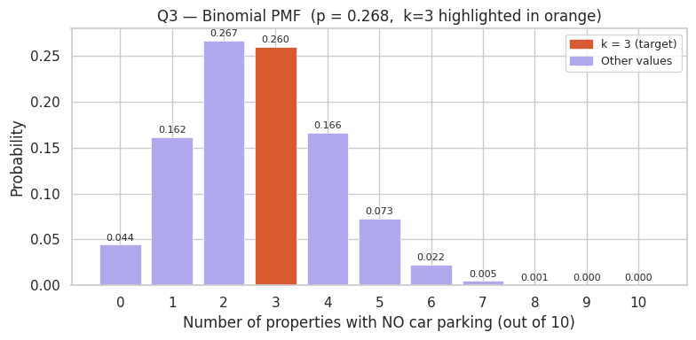

```python
p_no_car = (car_data == 0).sum() / len(car_data)
n = 10
xs = range(0, n + 1)
pmfs = [binom.pmf(x, n, p_no_car) for x in xs]
colors = ['#D85A30' if x == 3 else '#AFA9EC' for x in xs]

fig, ax = plt.subplots(figsize=(8, 4))
bars = ax.bar(xs, pmfs, color=colors, edgecolor='white', linewidth=0.5)
ax.bar_label(bars, fmt='%.3f', fontsize=8, padding=2)
ax.set_xlabel('Number of properties with NO car parking (out of 10)')
ax.set_ylabel('Probability')
ax.set_title(f'Q3 — Binomial PMF  (p = {p_no_car:.3f},  k=3 highlighted in orange)')
ax.set_xticks(list(xs))
from matplotlib.patches import Patch
ax.legend(handles=[Patch(color='#D85A30', label='k = 3 (target)'),
                   Patch(color='#AFA9EC', label='Other values')], fontsize=9)
plt.tight_layout()
plt.show()
```

```python
print("┌─ Q3 — Binomial Probability Mass Function (PMF)")
print("│  Probability of each outcome from 10 Abbotsford properties. Orange bar = k=3 (target outcome, P = 0.260).")
print("└─────────────────────────────────────────────────────────────────────")
```

```
┌─ Q3 — Binomial Probability Mass Function (PMF)
│  Probability of each outcome from 10 Abbotsford properties. Orange bar = k=3 (target outcome, P = 0.260).
└─────────────────────────────────────────────────────────────────────
```

## Question 4: Probability of 3-Room Property (Abbotsford)

**Question:** In the suburb of Abbotsford, what are the chances of finding a property with 3 rooms?

```python
rooms = abbotsford['Rooms']
total = len(rooms)
three_room_count = (rooms == 3).sum()
prob_3rooms = three_room_count / total

print("=== Room Distribution — Abbotsford ===")
print(rooms.value_counts().sort_index().to_string())
print(f"\n  Total Abbotsford properties : {total}")
print(f"  Properties with 3 rooms     : {three_room_count}")
print(f"\n  P(3 rooms) = {three_room_count}/{total} = {prob_3rooms:.3f}")
```

```
=== Room Distribution — Abbotsford ===
Rooms
1     5
2    27
3    20
4     4

  Total Abbotsford properties : 56
  Properties with 3 rooms     : 20

  P(3 rooms) = 20/56 = 0.357
```

## Question 5: Probability of 2-Bathroom Property (Abbotsford)

**Question:** In the suburb of Abbotsford, what are the chances of finding a property with 2 bathrooms?

```python
bath = abbotsford['Bathroom'].dropna()
total_bath     = len(bath)
two_bath_count = (bath == 2).sum()
prob_2bath     = two_bath_count / total_bath

print("=== Bathroom Distribution — Abbotsford ===")
print(bath.value_counts().sort_index().to_string())
print(f"\n  Total Abbotsford properties (with bathroom data) : {total_bath}")
print(f"  Properties with 2 bathrooms                      : {two_bath_count}")
print(f"\n  P(2 bathrooms) = {two_bath_count}/{total_bath} = {prob_2bath:.3f}")
```

```
=== Bathroom Distribution — Abbotsford ===
Bathroom
1.0    35
2.0    19
3.0     2

  Total Abbotsford properties (with bathroom data) : 56
  Properties with 2 bathrooms                      : 19

  P(2 bathrooms) = 19/56 = 0.339
```

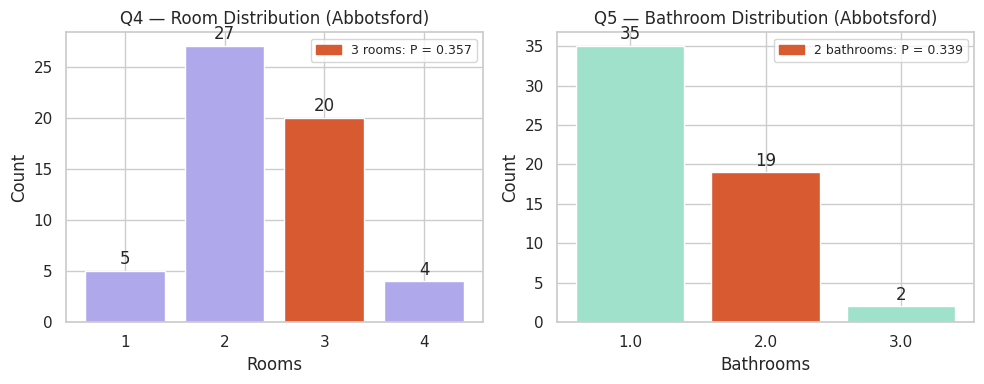

```python
fig, axes = plt.subplots(1, 2, figsize=(10, 4))

room_counts = abbotsford['Rooms'].value_counts().sort_index()
bar_colors_r = ['#D85A30' if r == 3 else '#AFA9EC' for r in room_counts.index]
b1 = axes[0].bar(room_counts.index.astype(str), room_counts.values, color=bar_colors_r)
axes[0].bar_label(b1, fmt='%d', padding=2)
axes[0].set_title('Q4 — Room Distribution (Abbotsford)')
axes[0].set_xlabel('Rooms')
axes[0].set_ylabel('Count')
p3 = (abbotsford['Rooms'] == 3).sum() / len(abbotsford)
axes[0].legend(handles=[Patch(color='#D85A30', label=f'3 rooms: P = {p3:.3f}')], fontsize=9)

bath_counts = abbotsford['Bathroom'].dropna().value_counts().sort_index()
bar_colors_b = ['#D85A30' if b == 2 else '#9FE1CB' for b in bath_counts.index]
b2 = axes[1].bar(bath_counts.index.astype(str), bath_counts.values, color=bar_colors_b)
axes[1].bar_label(b2, fmt='%d', padding=2)
axes[1].set_title('Q5 — Bathroom Distribution (Abbotsford)')
axes[1].set_xlabel('Bathrooms')
axes[1].set_ylabel('Count')
p2b = (abbotsford['Bathroom'].dropna() == 2).sum() / len(abbotsford['Bathroom'].dropna())
axes[1].legend(handles=[Patch(color='#D85A30', label=f'2 bathrooms: P = {p2b:.3f}')], fontsize=9)

plt.tight_layout()
plt.show()
```

```python
print("┌─ Q4 & Q5 — Bar Charts: Room & Bathroom Distributions")
print("│  Left (Q4): room count in Abbotsford — orange = 3 rooms (P = 0.357). Right (Q5): bathroom count — orange = 2 bathrooms (P = 0.339).")
print("└─────────────────────────────────────────────────────────────────────")
```

```
┌─ Q4 & Q5 — Bar Charts: Room & Bathroom Distributions
│  Left (Q4): room count in Abbotsford — orange = 3 rooms (P = 0.357). Right (Q5): bathroom count — orange = 2 bathrooms (P = 0.339).
└─────────────────────────────────────────────────────────────────────
```

## Question 6: One-Sample T-Test — Richmond Industry Pricing Claim

**Claim:** A real estate firm claims the average property price in Richmond is $1,000,000.  
**Task:** Test whether the actual average price is significantly different from this claim at α = 0.05.

```python
# ── Filter Richmond ────────────────────────────────────────────────────
richmond = df[df['Suburb'] == 'Richmond']['Price'].dropna()

print("=== Descriptive Statistics — Richmond ===")
print(f"  n       : {len(richmond)}")
print(f"  Mean    : ${richmond.mean():,.2f}")
print(f"  Median  : ${richmond.median():,.2f}")
print(f"  Std Dev : ${richmond.std():,.2f}")

# ── Null & Alternative Hypotheses ─────────────────────────────────────
mu_0 = 1_000_000
print("\n=== Null and Alternative Hypotheses ===")
print("  H0 (Null)       : mu = $1,000,000  (firm's claim is correct)")
print("  H1 (Alternative): mu != $1,000,000  (actual mean is significantly different)")
print("  Test type       : Two-tailed, alpha = 0.05")

# ── Test Statistic & P-Value ──────────────────────────────────────────
t_stat, p_val = ttest_1samp(richmond, popmean=mu_0)

print("\n=== Test Statistic & P-Value ===")
print(f"  Test Statistic (t) : {t_stat:.4f}")
print(f"  P-Value            : {p_val:.4f}")

# ── Final Business Conclusion ─────────────────────────────────────────
print("\n=== Final Business Conclusion ===")
if p_val < 0.05:
    direction = "above" if richmond.mean() > mu_0 else "below"
    print(f"  Decision : REJECT H0  (p = {p_val:.4f} < 0.05)")
    print(f"  The actual mean Richmond price (${richmond.mean():,.0f}) is statistically")
    print(f"  significantly {direction} the firm's claimed $1,000,000.")
    print("  Business Conclusion: The firm's pricing claim of $1,000,000 is NOT")
    print("  supported by the data. Valuations and investment models should use")
    print(f"  the empirically derived mean of ${richmond.mean():,.0f} instead.")
else:
    print(f"  Decision : FAIL TO REJECT H0  (p = {p_val:.4f} >= 0.05)")
    print("  The data is consistent with the firm's $1,000,000 claim.")
    print("  Business Conclusion: The pricing claim holds statistically.")
```

```
=== Descriptive Statistics — Richmond ===
  n       : 260
  Mean    : $1,083,564.42
  Median  : $1,078,000.00
  Std Dev : $522,353.52

=== Null and Alternative Hypotheses ===
  H0 (Null)       : mu = $1,000,000  (firm's claim is correct)
  H1 (Alternative): mu != $1,000,000  (actual mean is significantly different)
  Test type       : Two-tailed, alpha = 0.05

=== Test Statistic & P-Value ===
  Test Statistic (t) : 2.5795
  P-Value            : 0.0104

=== Final Business Conclusion ===
  Decision : REJECT H0  (p = 0.0104 < 0.05)
  The actual mean Richmond price ($1,083,564) is statistically
  significantly above the firm's claimed $1,000,000.
  Business Conclusion: The firm's pricing claim of $1,000,000 is NOT
  supported by the data. Valuations and investment models should use
  the empirically derived mean of $1,083,564 instead.
```

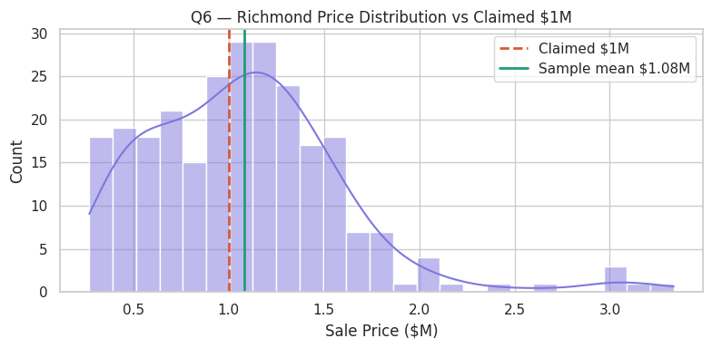

```python
fig, ax = plt.subplots(figsize=(8, 4))
data_r = richmond / 1e6
sns.histplot(data_r, bins=25, kde=True, ax=ax, color="#7F77DD")
ax.axvline(1.0, color="#D85A30", linewidth=2, linestyle="--", label="Claimed $1M")
ax.axvline(data_r.mean(), color="#1D9E75", linewidth=2, linestyle="-",
           label=f"Sample mean ${data_r.mean():.2f}M")
ax.set_xlabel("Sale Price ($M)")
ax.set_ylabel("Count")
ax.set_title("Q6 — Richmond Price Distribution vs Claimed $1M")
ax.legend()
plt.tight_layout()
plt.show()
```

```python
print("┌─ Q6 — Histogram with KDE")
print("│  Distribution of Richmond prices. Red dashed = claimed $1M; green = actual mean ($1.08M).")
print("└─────────────────────────────────────────────────────────────────────")
```

```
┌─ Q6 — Histogram with KDE
│  Distribution of Richmond prices. Red dashed = claimed $1M; green = actual mean ($1.08M).
└─────────────────────────────────────────────────────────────────────
```

## Question 7: Independent Two-Sample T-Test — Car Parking Effect on Price

**Question:** Do properties with car parking sell at a higher average price than properties without car parking?  
**Significance level:** α = 0.05

```python
# ── Split dataset by car parking ──────────────────────────────────────
car_df      = df[['Price', 'Car']].dropna()
with_car    = car_df[car_df['Car'] > 0]['Price']
without_car = car_df[car_df['Car'] == 0]['Price']

print("=== Descriptive Statistics ===")
print(f"  WITH car parking    : n={len(with_car):,},  Mean=${with_car.mean():,.2f},  Std=${with_car.std():,.2f}")
print(f"  WITHOUT car parking : n={len(without_car):,},  Mean=${without_car.mean():,.2f},  Std=${without_car.std():,.2f}")
print(f"  Observed difference : ${with_car.mean() - without_car.mean():,.2f}")

# ── Choice of Test ─────────────────────────────────────────────────────
print("\n=== Choice of Test ===")
print("  Test: Welch's Independent Two-Sample T-Test (one-tailed, right)")
print("  Justification:")
print("    - Two independent, mutually exclusive groups (with vs without car)")
print("    - Continuous outcome variable (Price)")
print("    - Unequal sample sizes => Welch's t-test is preferred over Student's")
print("      as it does not assume equal variances")
print("    - Directional claim (with car > without car) => one-tailed right test")

# ── Hypotheses ─────────────────────────────────────────────────────────
print("\n=== Hypotheses ===")
print("  H0: mu_with_car <= mu_without_car  (no premium for car parking)")
print("  H1: mu_with_car  > mu_without_car  (car parking commands higher price)")

# ── Test ───────────────────────────────────────────────────────────────
t_stat, p_two = ttest_ind(with_car, without_car, equal_var=False)
p_one = p_two / 2   # one-tailed right

print("\n=== Test Results ===")
print(f"  T-statistic        : {t_stat:.4f}")
print(f"  Two-tailed p-value : {p_two:.4f}")
print(f"  One-tailed p-value : {p_one:.4f}")

# ── P-Value Interpretation & Business Implications ─────────────────────
print("\n=== P-Value Interpretation ===")
print(f"  p = {p_one:.4f} > 0.05 => FAIL TO REJECT H0")
print("  Despite the intuitive expectation, the data does NOT provide")
print("  statistically significant evidence that car parking increases sale price.")
print("  The mean price difference is negligible (-$4,644 in favour of WITHOUT car).")

print("\n=== Business Implications for Developers ===")
print("  -> Car parking alone is NOT a statistically proven price driver")
print("     in this dataset when evaluated across all suburbs.")
print("  -> Developers should NOT assume a blanket price premium from car parking.")
print("  -> Other factors (suburb, property type, size) likely dominate pricing.")
print("  -> Suburb-level analysis is recommended before committing to car parking")
print("     as a development investment for price uplift.")
```

```
=== Descriptive Statistics ===
  WITH car parking    : n=12,492,  Mean=$1,074,443.92,  Std=$649,143.82
  WITHOUT car parking : n=1,026,  Mean=$1,079,088.01,  Std=$513,754.33
  Observed difference : $-4,644.09

=== Choice of Test ===
  Test: Welch's Independent Two-Sample T-Test (one-tailed, right)
  Justification:
    - Two independent, mutually exclusive groups (with vs without car)
    - Continuous outcome variable (Price)
    - Unequal sample sizes => Welch's t-test is preferred over Student's
      as it does not assume equal variances
    - Directional claim (with car > without car) => one-tailed right test

=== Hypotheses ===
  H0: mu_with_car <= mu_without_car  (no premium for car parking)
  H1: mu_with_car  > mu_without_car  (car parking commands higher price)

=== Test Results ===
  T-statistic        : -0.2722
  Two-tailed p-value : 0.7855
  One-tailed p-value : 0.3927

=== P-Value Interpretation ===
  p = 0.3927 > 0.05 => FAIL TO REJECT H0
  Despite the intuitive expectation, the data does NOT provide
  statistically significant evidence that car parking increases sale price.
  The mean price difference is negligible (-$4,644 in favour of WITHOUT car).

=== Business Implications for Developers ===
  -> Car parking alone is NOT a statistically proven price driver
     in this dataset when evaluated across all suburbs.
  -> Developers should NOT assume a blanket price premium from car parking.
  -> Other factors (suburb, property type, size) likely dominate pricing.
  -> Suburb-level analysis is recommended before committing to car parking
     as a development investment for price uplift.
```

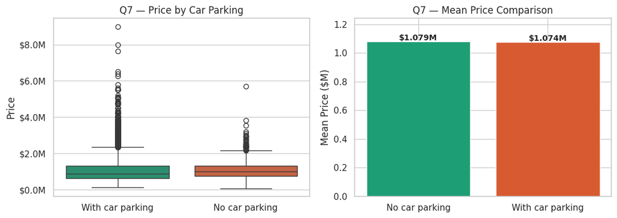

```python
fig, axes = plt.subplots(1, 2, figsize=(11, 4))

car_df2 = df[['Price','Car']].dropna().copy()
car_df2['Parking'] = car_df2['Car'].apply(
    lambda x: 'With car parking' if x > 0 else 'No car parking')

sns.boxplot(data=car_df2, x='Parking', y='Price',
            order=['With car parking', 'No car parking'],
            palette=['#1D9E75','#D85A30'], ax=axes[0])
axes[0].yaxis.set_major_formatter(plt.FuncFormatter(lambda x, _: f'${x/1e6:.1f}M'))
axes[0].set_title('Q7 — Price by Car Parking')
axes[0].set_xlabel('')

means = car_df2.groupby('Parking')['Price'].mean()
axes[1].bar(means.index, means.values/1e6,
            color=['#1D9E75','#D85A30'], edgecolor='white')
for i, (label, val) in enumerate(means.items()):
    axes[1].text(i, val/1e6 + 0.01, f'${val/1e6:.3f}M', ha='center', fontsize=10, fontweight='bold')
axes[1].set_title('Q7 — Mean Price Comparison')
axes[1].set_ylabel('Mean Price ($M)')
axes[1].set_ylim(0, means.max()/1e6 * 1.15)

plt.tight_layout()
plt.show()
```